# Test 1

Michal Moudrý

4/10/2020

## Obsah

- Definice proměnných a funkcí
- První úkol
- Druhý úkol
- Třetí úkol

## Definice proměnných a funkcí

```r
osoby <- data.frame(
  "osoba" = 1:30,
  "IQ" = c(94, 75, 93, 91, 88, 79, 88, 84, 92, 90, 97, 100, 82, 86, 110, 96, 90, 92, 92, 99, 96, 103, 97, 88, 93, 90, 85, 86, 96, 86))
rozptyl <- function(hodnoty) {
  return((sum((hodnoty-mean(hodnoty))^2))/(length(hodnoty)))
}
odchylka <- function(hodnoty) {
  return(sqrt((sum((hodnoty-mean(hodnoty))^2))/(length(hodnoty))))
}
var_koef <- function(hodnoty) {
  return((sqrt((sum((hodnoty-mean(hodnoty))^2))/(length(hodnoty))))/mean(hodnoty))
}
tabulkaOsob <- table(osoby$IQ)
tabulkaOsob <- as.data.frame(tabulkaOsob)
colnames(tabulkaOsob) = c("IQ", "Frekvence")
tabulkaOsob$Relativni_cetnost <- tabulkaOsob$Frekvence/sum(tabulkaOsob$Frekvence)
```

## První úkol

### a)

Identifikujte, o jakou statistickou proměnnou jde (kvantitativní spojitá, kvantitativní nespojitá, kvalitativní nominální, kvalitativní ordinální).

`Odpověď`: Jde o kvantitativní nespojitou (diskrétní) statistickou proměnnou.

### b)

S využitím vhodného typu grafu vizualizujte hodnoty tohoto statistického znaku.

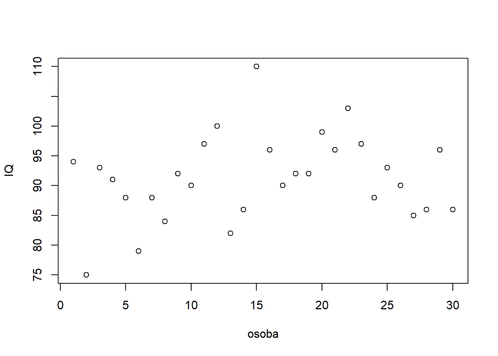

```r
plot(osoby)
```

### c)

Vypočítejte aritmetický, harmonický a geometrický průměr IQ a uveďte, který z nich se nejlépe hodí pro popis průměrné hodnoty tohoto ukazatele a proč.

`Odpověď`: V případě ukazatele IQ je asi nejvhodnější harmonický průměr, protože daný průměr je vhodný pro sadu čísel, jež mají vztah k nějaké jednotce (např. jednotka času), tedy by se hodil pro popis jednotky inteligenčního kvocientu.

#### Aritmetický průměr

```r
sum(osoby$IQ)/length(osoby$IQ)
```

```
## [1] 91.26667
```

#### Harmonický průměr

```r
length(osoby$IQ)/sum(1/osoby$IQ)
```

```
## [1] 90.7236
```

#### Geometrický průměr

```r
exp(mean(log(osoby$IQ)))
```

```
## [1] 90.99546
```

### d)

Vypočítejte další charakteristiky polohy: minimum, maximum, modus (pokud existuje), medián, horní a dolní kvartil a všechny hodnoty slovně interpretujte.

#### Minimum

```r
min(osoby$IQ)
```

```
## [1] 75
```

`Slovní interpretace`: Hodnota minima statistického znaku IQ je 75, což znamená, že nejmenší hodnota v daném souboru je 75 IQ.

#### Maximum

```r
max(osoby$IQ)
```

```
## [1] 110
```

`Slovní interpretace`: Hodnota maxima statistického znaku IQ je 110, což znamená, že největší hodnota v daném souboru je 110 IQ.

#### Modus

```r
library(modeest)
mfv(sort(osoby$IQ))
```

```
## [1] 86 88 90 92 96
```

#### Medián

```r
median(sort(osoby$IQ))
```

```
## [1] 91.5
```

`Slovní interpretace`: Hodnota mediánu je 91.5, což znamená, že 50% hodnot ve statistickém souboru jsou menší než 91.5 IQ.

#### Horní kvartil

```r
quantile(osoby$IQ, probs = 0.75)
```

```
## 75%
##  96
```

`Slovní interpretace`: Hodnota horního kvartilu je 96, což znamená, že 75% hodnot ve statistickém souboru je menší než 96 IQ.

#### Dolní kvartil

```r
quantile(osoby$IQ, probs = 0.25)
```

```
##  25%
## 86.5
```

`Slovní interpretace`: Hodnota dolního kvartilu je 86.5, což znamená, že 25% hodnot ve statistickém souboru jsou menší než 86.5 IQ.

### e)

Vypočítejte míry absolutní variability: variační rozpětí, kvartilové rozpětí, rozptyl a směrodatnou odchylku a všechny hodnoty slovně interpretujte.

#### Variační rozpětí

```r
max(osoby$IQ) - min(osoby$IQ)
```

```
## [1] 35
```

`Slovní interpretace`: Hodnota variačního rozpětí je 35, což je hodnota, která určuje vzdálenost mezi nejmenší a největší hodnotou v datasetu, tedy v tomto případě mezi hodnotou 110 a 75.

#### Kvartilové rozpětí

```r
quantile(osoby$IQ, probs = 0.75) - quantile(osoby$IQ, probs = 0.25)
```

```
## 75%
## 9.5
```

`Slovní interpretace`: Hodnota kvartilového rozpětí je 9.5, což je hodnota, která označuje rozdíl mezi horním a dolním kvartilem, tedy v tomto případě mezi hodnotami 96 a 86.5.

#### Rozptyl

```r
rozptyl(osoby$IQ)
```

```
## [1] 49.52889
```

`Slovní interpretace`: Hodnota rozptylu je 49.52889, přičemž tato hodnota udává variablitu ve statistickém souboru.

#### Směrodatná odchylka

```r
odchylka(osoby$IQ)
```

```
## [1] 7.037676
```

`Slovní interpretace`: Hodnota směrodatné odchylky je 7.037676, což je hodnota získaná odmocněním rozptylu a vypovídá o tom, nakolik se od sebe liší jednotlivé prvky v souboru.

### f)

Vypočítejte míru relativní variability: variační koeficient a danou hodnotu slovně interpretujte.

`Poznámka`: Tady jsem myslel, že mám míru variablity spočítat pomocí rozptylu z relativní četnosti (nevěděl jsem, že mi vyjde stejný výsledek jako u rozptylu), ale rozhodl jsem se to tu nechat

#### Rozptyl z relativní četnosti

```r
tabulkaCetnostiIQ <- as.data.frame(as.numeric(levels(tabulkaOsob$IQ)))
colnames(tabulkaCetnostiIQ) = c("IQ");
rozptyl_z_rel_cetnosti <- sum(((tabulkaCetnostiIQ$IQ - mean(tabulkaCetnostiIQ$IQ))^2)*tabulkaOsob$Relativni_cetnost)
rozptyl_z_rel_cetnosti
```

```
## [1] 49.53333
```

#### Variační koeficient

```r
sqrt(rozptyl_z_rel_cetnosti)/mean(osoby$IQ)
```

```
## [1] 0.0771146
```

`Slovní interpretace`: Variační koeficient se používá pro porovnání variablity mezi dvěmi datasety, je to tedy hodnota vyjadřující poměr mezi směrodatnou odchylkou a průměrnou hodnotou statistického znaku v souboru.

### g)

Odpovídá podle Vás analyzovaná proměnná IQ normálnímu rozdělení? Uveďte argumenty, které podporují Vaše rozhodnutí.

`Odpověď`: Ano, z větší části odpovídá křivce hustoty normálního rozdělení, tedy nejméně hodnot je na začátku, na konci a nějvětší počet hodnot je kolem středu (průměru). Danou skutečnost lze vidět na histogramu IQ osob v souboru.

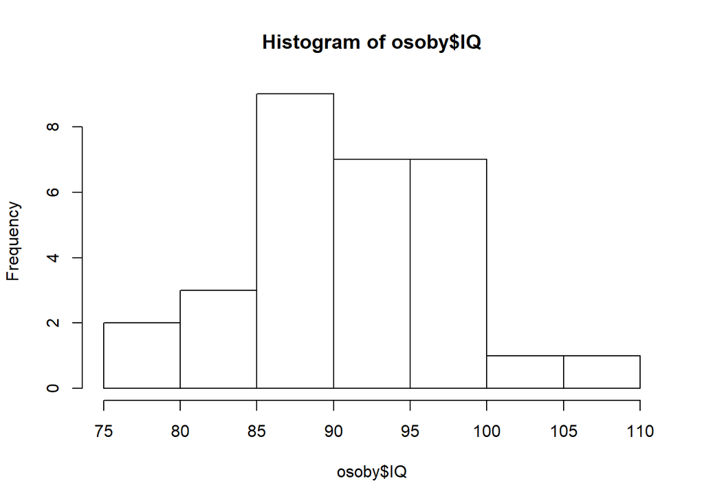

```r
hist(osoby$IQ)
```

## Druhý úkol

Jaká je pravděpodobnost, že z 9 kol losování rulety obdržíme:

1. 6-krát číslo červené barvy
2. 8-krát liché číslo
3. maximálně 4-krát číslo dělitelné 4
4. alespoň 8-krát číslo větší než 7

V tomto cvičení jsem použil vzorce binomockého rozdělení, tedy pro výpočet pravděpodobnostní funkce jsem použil funkci dbinom a pro výpočet distribuční funkce jsem použil pbinom.

### a) 6-krát číslo červené barvy

x = 6 … označuje kolikrát má padnout červená barva

n (size) = 9 … počet pokusů

prob = počet červených čísel / počtem všech čísel (včetně nuly) = choose(18, 1) / choose(37, 1) = 18 / 37

```r
dbinom(x = 6, size = 9, prob = 18 / 37)
```

```
## [1] 0.1507855
```

`Slovní odpověď`: Pravděpodobnost, že z 9 kol losování rulety obdržíme 6-krát číslo červené barvy je přibližně 15,1 %.

### b) 8-krát liché číslo

x = 8 … označuje kolikrát má padnout liché číslo

n (size) = 9 … počet pokusů

prob = počet lichých čísel / počtem všech čísel (včetně nuly) = choose(18, 1) / choose(37, 1) = 18 / 37

```r
dbinom(x = 8, size = 9, prob = 18 / 37)
```

```
## [1] 0.01449975
```

`Slovní odpověď`: Pravděpodobnost, že z 9 kol losování rulety obdržíme 8-krát liché číslo je přibližně 1,5 %.

### c) maximálně 4-krát číslo dělitelné 4

q = 4 … označuje kolikrát maximálně má padnout číslo dělitelné 4

n (size) = 9 … počet pokusů

prob = počet čísel dělitelných 4 / počtem všech čísel (včetně nuly) = choose(9, 1) / choose(37, 1) = 9 / 37

```r
pbinom(q = 4, size = 9, prob = 9 / 37)
```

```
## [1] 0.956146
```

`Slovní odpověď`: Pravděpodobnost, že z 9 kol losování rulety obdržíme maximálně 4-krát číslo dělitelné 4 je přibližně 95,6 %.

### d) alespoň 8-krát číslo větší než 7

počet čísel větších než 7 = 29

q = 8 … označuje kolikrát má padnout číslo větší než 7 (>=)

n (size) = 9 … počet pokusů

```r
1 - pbinom(q = 8, size = 9, prob = 29 / 37)
```

```
## [1] 0.1116263
```

## Třetí úkol

Výsledek měření proudu je náhodná veličina X s normálním rozdělením se střední hodnotou 𝜇 = 10 mA a směrodatnou odchylkou 𝜎 = 2 mA. Vypočítejte pravděpodobnost, že při náhodném měření bude naměřeno:

1. méně než 14 mA
2. více než 6 mA
3. více než 6 mA a méně než 14 mA
4. jakou hodnotu v mA překročí 85 % měření

V rámci tohoto cvičení jsem použil vzorce normálního rozdělení a to konkrétně pro výpočet distribuční funkce (pnorm) a qnorm pro vyhlednání hodnot z tabulek.

### a) méně než 14 mA

`Poznámka`: Z hodin elektrotechniky si toho moc nepamatuji, ale nemyslím si, že proud by mohl jít do záporu, což by odpovídalo koncepci Gaussovy diody, proto jsem zvolil rozmezí <0;13>

q2 … horní hodnota rozmezí (chceme hodnoty menší než 14 mA proto je q2 rovno 13) = 13

q1 … dolní hodnota rozmezí (minimální naměřený proud) = 0

mean … střední hodnota = 10

sd … směrodatná odchylka = 2

```r
pnorm(q = 13, mean = 10, sd = 2) - pnorm(q = 0, mean = 10, sd = 2)
```

```
## [1] 0.9331925
```

```r
# pnorm(q = 0, mean = 10, sd = 2) ... přestože se nejedná o velké číslo, tak dle mé poznámky by se mělo odečíst.
```

### b) více než 6 mA

mean … střední hodnota = 10

sd … směrodatná odchylka = 2

```r
pnorm(q = 6, mean = 10, sd = 2, lower.tail = FALSE)
```

```
## [1] 0.9772499
```

`Slovní interpretace`: Pravděpodobnost, že naměříme proud větší než 6 mA je přibližně 97,7 %.

### c) více než 6 mA a méně než 14 mA

q1 … dolní hodnota rozmezí = 7

q2 … horní hodnota rozmezí = 13

mean … střední hodnota = 10

sd = směrodatná odchylka = 2

```r
pnorm(q = 13, mean = 10, sd = 2) - pnorm(q = 7, mean = 10, sd = 2)
```

```
## [1] 0.8663856
```

### d) jakou hodnotu v mA překročí 85 % měření

Výpočet 85 % kvantilu - x0,85

x0,85 = u0,85 * 𝜎 + 𝜇

u0,85 = 1.036433

𝜎 = 2

𝜇 = 10

x0,85 = 1.036433 * 2 + 10 = 12.07287

```r
qnorm(p = 0.85, mean = 0, sd = 1)
```

```
## [1] 1.036433
```

```r
x0.85 <- qnorm(p = 0.85, mean = 0, sd = 1) * 2 + 10
x0.85
```

```
## [1] 12.07287
```